# sensitivity_summary

2024-09-05

```
## [1] 241378    186
```

# Sensitivity Analyses

Sensitivity analysis sample among all EUR participants

|  | Total |
| --- | --- |
| N (%) | 362458 |
| Genotyping, n(%) | 362075 (99.9%) |
| T2D controls, n(%) | 279805 (77.2%) |
| Complete covariate data, n(%) | 359244 (99.1%) |
| Complete fasting data, n(%) | 362445 (100%) |
| Complete fasting data for <24hr, n(%) | 362419 (100%) |
| Available 24HR data, n (%) | 143928 (39.7%) |
| Total sample for sensitivity analysis, N (%) | 277190 (76.5%) |

## I. Additionally adjust for ALL 24 diet PCs

Associations of TAS2R38 with Glycemic Measures, Adjusting for All 24 Diet PCs

| Model | Exposure | N | Beta_95CI | P_t.test | P_f.test | P_trend.test |
| --- | --- | --- | --- | --- | --- | --- |
| 1 | AVI/AVI | 73524 | - | - | 0.050964 | 0.032229 |
| 2 | AVI/PAV | 106591 | -0.003 (-0.008, 0.002) | 0.294866 | - | - |
| 3 | PAV/PAV | 38573 | -0.008 (-0.015, -0.001) | 0.029192 | - | - |
| 4 | AVI/AVI | 19489 | - | - | 0.01577 | 0.003912 |
| 5 | AVI/PAV | 28110 | -0.014 (-0.027, -0.001) | 0.037235 | - | - |
| 6 | PAV/PAV | 10053 | -0.024 (-0.042, -0.007) | 0.006169 | - | - |
| 7 | AVI/AVI | 73524 | - | - | 0.211803 | 0.492741 |
| 8 | AVI/PAV | 106591 | 0.002 (-0.001, 0.004) | 0.148138 | - | - |
| 9 | PAV/PAV | 38573 | 0.001 (-0.003, 0.004) | 0.706936 | - | - |

## II. Additionally adjust for fiber-to-carbohydrate ratio

Analyses were performed in a subsample of participants with who **completed 24HRs** and had plausible values for total energy intake (kcal/day) derived using from self-reported intakes.

Plausible energy intake was defined as: *for M: 600- 4880 kcal/day (~20 MJ)* for F: 600- 4300 kcal/day (~18 MJ)

Decription of subsample with available and plausible 24HR data

| X | Total | Plausible.24HR | No.24HR | P_value | P_trend |
| --- | --- | --- | --- | --- | --- |
| N (%) | 241378 | 98325 (40.7%) | 143053 (59.3%) | - | - |
| TAS2R38 diplotype |  |  |  | 0.5105 | - |
| AVI/AVI | 73524 (33.6%) | 30063 (30.6%) | 43461 (30.4%) |  |  |
| AVI/PAV | 106591 (48.7%) | 43293 (44%) | 63298 (44.2%) |  |  |
| PAV/PAV | 38573 (17.6%) | 15717 (16%) | 22856 (16%) |  |  |
| Age, years | 56.05 ± 8.09 | 55.81 ± 7.92 | 56.21 ± 8.19 | 0 | 0 |
| Sex |  |  |  | 0.0025 | - |
| Male | 110405 (45.7%) | 44609 (45.4%) | 65796 (46%) |  |  |
| Female | 130973 (54.3%) | 53716 (54.6%) | 77257 (54%) |  |  |
| BMI, kg/m2 | 26.86 ± 4.38 | 26.43 ± 4.26 | 27.15 ± 4.45 | 0 | 0 |
| Smoking |  |  |  | 0 | - |
| Never | 135682 (56.2%) | 57191 (58.2%) | 78491 (54.9%) |  |  |
| Previous | 83002 (34.4%) | 34275 (34.9%) | 48727 (34.1%) |  |  |
| Current | 22694 (9.4%) | 6859 (7%) | 15835 (11.1%) |  |  |
| Physical Activity, MET/wk |  |  |  | 0 | - |
| Low | 54898 (22.7%) | 22556 (22.9%) | 32342 (22.6%) |  |  |
| Moderate | 136482 (56.5%) | 56971 (57.9%) | 79511 (55.6%) |  |  |
| High | 49998 (20.7%) | 18798 (19.1%) | 31200 (21.8%) |  |  |
| Alcohol Frequency |  |  |  | 0 | - |
| Daily or almost daily | 54085 (22.4%) | 24072 (24.5%) | 30013 (21%) |  |  |
| 3-4 per week | 60903 (25.2%) | 26151 (26.6%) | 34752 (24.3%) |  |  |
| 1-2 per week | 63566 (26.3%) | 24643 (25.1%) | 38923 (27.2%) |  |  |
| 1-3 per month | 25859 (10.7%) | 10197 (10.4%) | 15662 (10.9%) |  |  |
| Special occasions only | 22932 (9.5%) | 8244 (8.4%) | 14688 (10.3%) |  |  |
| Never1 | 14033 (5.8%) | 5018 (5.1%) | 9015 (6.3%) |  |  |
| Education Level |  |  |  | 0 | - |
| Level 1 | 35930 (15%) | 7664 (7.8%) | 28266 (19.8%) |  |  |
| Level 2 | 65928 (27.5%) | 24538 (25%) | 41390 (28.9%) |  |  |
| Level 3 | 28568 (11.9%) | 13272 (13.5%) | 15296 (10.7%) |  |  |
| Level 4 | 12036 (5%) | 4693 (4.8%) | 7343 (5.1%) |  |  |
| Level 5 | 97086 (40.5%) | 47826 (48.6%) | 49260 (34.4%) |  |  |
| Income Level |  |  |  | 0 | - |
| lt_18000 | 40834 (19.4%) | 12259 (12.5%) | 28575 (20%) |  |  |
| from_18000_to_30999 | 51872 (24.7%) | 21075 (21.4%) | 30797 (21.5%) |  |  |
| from_31000_to_51999 | 57310 (27.3%) | 25771 (26.2%) | 31539 (22%) |  |  |
| from_52000_to_100000 | 47301 (22.5%) | 22957 (23.3%) | 24344 (17%) |  |  |
| gt_100000 | 12665 (6%) | 6762 (6.9%) | 5903 (4.1%) |  |  |

Assessment Center x 24HR

[output not shown]

| X | Total | Has.24HR | No.24HR | P_value | P_trend |
| --- | --- | --- | --- | --- | --- |
| N (%) | 241378 | 98406 (40.8%) | 142972 (59.2%) | - | - |
| Assessment Center |  |  |  | 0 | - |
| Barts | 4987 (2.1%) | 2312 (2.3%) | 2675 (1.9%) |  |  |
| Birmingham | 11186 (4.6%) | 6329 (6.4%) | 4857 (3.4%) |  |  |
| Bristol | 22198 (9.2%) | 10900 (11.1%) | 11298 (7.9%) |  |  |
| Bury | 14119 (5.8%) | 3591 (3.6%) | 10528 (7.4%) |  |  |
| Cardiff | 9605 (4%) | 2636 (2.7%) | 6969 (4.9%) |  |  |
| Croydon | 11477 (4.8%) | 7709 (7.8%) | 3768 (2.6%) |  |  |
| Edinburgh | 9225 (3.8%) | 3286 (3.3%) | 5939 (4.2%) |  |  |
| Glasgow | 9139 (3.8%) | 2040 (2.1%) | 7099 (5%) |  |  |
| Hounslow | 11350 (4.7%) | 7853 (8%) | 3497 (2.4%) |  |  |
| Leeds | 21809 (9%) | 6751 (6.9%) | 15058 (10.5%) |  |  |
| Liverpool | 15567 (6.4%) | 7259 (7.4%) | 8308 (5.8%) |  |  |
| Manchester | 6637 (2.7%) | 1872 (1.9%) | 4765 (3.3%) |  |  |
| Middlesborough | 10265 (4.3%) | 4748 (4.8%) | 5517 (3.9%) |  |  |
| Newcastle | 18261 (7.6%) | 4628 (4.7%) | 13633 (9.5%) |  |  |
| Nottingham | 16606 (6.9%) | 5747 (5.8%) | 10859 (7.6%) |  |  |
| Oxford | 7505 (3.1%) | 2675 (2.7%) | 4830 (3.4%) |  |  |
| Reading | 15476 (6.4%) | 6293 (6.4%) | 9183 (6.4%) |  |  |
| Sheffield | 14811 (6.1%) | 9386 (9.5%) | 5425 (3.8%) |  |  |
| Stoke | 9693 (4%) | 1826 (1.9%) | 7867 (5.5%) |  |  |
| Swansea | 1125 (0.5%) | 447 (0.5%) | 678 (0.5%) |  |  |
| Wrexham | 337 (0.1%) | 118 (0.1%) | 219 (0.2%) |  |  |

#### Bar plots of RG by 24HR data & fasting time

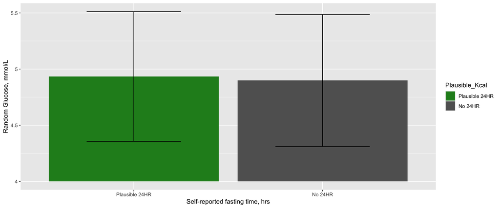

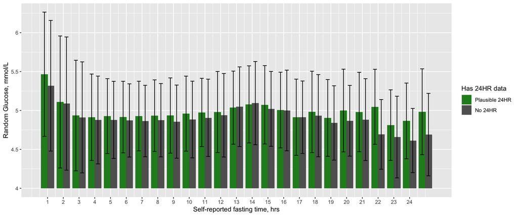

**Stratified models by 24HR data**

TAS2R38 diplotype with RG & 2hr glucose, adjusting for Fiber-to-Carbohydrate ratio

| Model | N | Beta_95CI | P_t.test | P_f.test | P_trend.test |
| --- | --- | --- | --- | --- | --- |
| Has 24HR: RG~Diet_AVI/AVI | 30063 | - | - | 0.050301 | 0.01647 |
| Has 24HR: RG~Diet_AVI/PAV | 43293 | -0.007 (-0.015, 0.002) | 0.122631 | - | - |
| Has 24HR: RG~Diet_PAV/PAV | 15717 | -0.013 (-0.024, -0.002) | 0.019599 | - | - |
| Has 24HR: RG~Fib2Car_AVI/AVI | 30014 | - | - | 0.047057 | 0.01578 |
| Has 24HR: RG~Fib2Car_AVI/PAV | 43234 | -0.007 (-0.015, 0.001) | 0.107006 | - | - |
| Has 24HR: RG~Fib2Car_PAV/PAV | 15700 | -0.013 (-0.024, -0.002) | 0.019683 | - | - |
| Has 24HR: RG~SES_AVI/AVI | 27147 | - | - | 0.128287 | 0.052894 |
| Has 24HR: RG~SES_AVI/PAV | 38952 | -0.007 (-0.016, 0.002) | 0.126507 | - | - |
| Has 24HR: RG~SES_PAV/PAV | 14154 | -0.011 (-0.022, 0.001) | 0.071719 | - | - |
| Has 24HR: 2hr Glu~Diet_AVI/AVI | 7736 | - | - | 0.06306 | 0.009709 |
| Has 24HR: 2hr Glu~Diet_AVI/PAV | 11171 | -0.02 (-0.04, 0.001) | 0.066966 | - | - |
| Has 24HR: 2hr Glu~Diet_PAV/PAV | 4002 | -0.035 (-0.062, -0.007) | 0.013681 | - | - |
| Has 24HR: 2hr Glu~Fib2Car_AVI/AVI | 7725 | - | - | 0.061028 | 0.009927 |
| Has 24HR: 2hr Glu~Fib2Car_AVI/PAV | 11154 | -0.02 (-0.041, 0.001) | 0.062551 | - | - |
| Has 24HR: 2hr Glu~Fib2Car_PAV/PAV | 3999 | -0.034 (-0.062, -0.007) | 0.014379 | - | - |
| Has 24HR: 2hr Glu~SES_AVI/AVI | 7085 | - | - | 0.062163 | 0.008609 |
| Has 24HR: 2hr Glu~SES_AVI/PAV | 10282 | -0.021 (-0.043, 0.001) | 0.056301 | - | - |
| Has 24HR: 2hr Glu~SES_PAV/PAV | 3635 | -0.036 (-0.065, -0.008) | 0.012808 | - | - |

TAS2R38 diplotype with RG & 2hr glucose, in subset without 24HR data (comparison)

| Model | N | Beta_95CI | P_t.test | P_f.test | P_trend.test |
| --- | --- | --- | --- | --- | --- |
| No 24HR: RG~Diet_AVI/AVI | 43461 | - | - | 0.459173 | 0.477709 |
| No 24HR: RG~Diet_AVI/PAV | 63298 | 0 (-0.007, 0.007) | 0.952535 | - | - |
| No 24HR: RG~Diet_PAV/PAV | 22856 | -0.004 (-0.013, 0.005) | 0.419979 | - | - |
| No 24HR: RG~SES_AVI/AVI | 36635 | - | - | 0.219936 | 0.180213 |
| No 24HR: RG~SES_AVI/PAV | 53413 | -0.001 (-0.009, 0.006) | 0.744319 | - | - |
| No 24HR: RG~SES_PAV/PAV | 19220 | -0.007 (-0.018, 0.003) | 0.144064 | - | - |
| No 24HR: 2hr Glu~Diet_AVI/AVI | 11753 | - | - | 0.195381 | 0.101689 |
| No 24HR: 2hr Glu~Diet_AVI/PAV | 16939 | -0.011 (-0.028, 0.007) | 0.227036 | - | - |
| No 24HR: 2hr Glu~Diet_PAV/PAV | 6051 | -0.018 (-0.04, 0.005) | 0.122196 | - | - |
| No 24HR: 2hr Glu~SES_AVI/AVI | 10157 | - | - | 0.045201 | 0.016041 |
| No 24HR: 2hr Glu~SES_AVI/PAV | 14717 | -0.013 (-0.032, 0.005) | 0.153657 | - | - |
| No 24HR: 2hr Glu~SES_PAV/PAV | 5232 | -0.029 (-0.053, -0.005) | 0.017344 | - | - |

#### NOTE: apparent confounding of SES on TAS2R38-glucose associations in the subsample without 24HR data

Based on a suggestion from KEW, consider whether this might be reflective of underlying associations of gPCs (10-20) with SES by additionally adjusting for all 20 gPCs in the diet model and comparing the changes in effect estimates

TAS2R38 diplotype with RG & 2hr glucose, in subset without 24HR data

| Model | Exposure | N | Beta_95CI | P_t.test | P_f.test | P_trend.test |
| --- | --- | --- | --- | --- | --- | --- |
| No 24HR: RG~Diet | AVI/AVI | 43461 | - | - | 0.464209 | 0.447827 |
| No 24HR: RG~Diet | AVI/PAV | 63298 | 0 (-0.007, 0.007) | 0.905709 | - | - |
| No 24HR: RG~Diet | PAV/PAV | 22856 | -0.004 (-0.013, 0.005) | 0.397395 | - | - |
| No 24HR: RG~SES | AVI/AVI | 36635 | - | - | 0.224826 | 0.17144 |
| No 24HR: RG~SES | AVI/PAV | 53413 | -0.001 (-0.009, 0.006) | 0.707692 | - | - |
| No 24HR: RG~SES | PAV/PAV | 19220 | -0.008 (-0.018, 0.002) | 0.139265 | - | - |
| No 24HR: RG~Assessment.Center | AVI/AVI | 43461 | - | - | 0.460141 | 0.459918 |
| No 24HR: RG~Assessment.Center | AVI/PAV | 63298 | 0 (-0.007, 0.007) | 0.971625 | - | - |
| No 24HR: RG~Assessment.Center | PAV/PAV | 22856 | -0.004 (-0.013, 0.005) | 0.396983 | - | - |
| No 24HR: 2hr Glu~Diet | AVI/AVI | 11753 | - | - | 0.19847 | 0.123935 |
| No 24HR: 2hr Glu~Diet | AVI/PAV | 16939 | -0.01 (-0.027, 0.008) | 0.276613 | - | - |
| No 24HR: 2hr Glu~Diet | PAV/PAV | 6051 | -0.017 (-0.04, 0.006) | 0.142347 | - | - |
| No 24HR: 2hr Glu~SES | AVI/AVI | 10157 | - | - | 0.046658 | 0.022272 |
| No 24HR: 2hr Glu~SES | AVI/PAV | 14717 | -0.012 (-0.03, 0.006) | 0.198812 | - | - |
| No 24HR: 2hr Glu~SES | PAV/PAV | 5232 | -0.028 (-0.052, -0.004) | 0.02265 | - | - |
| No 24HR: 2hr Glu~Assessment.Center | AVI/AVI | 11753 | - | - | 0.196104 | 0.108093 |
| No 24HR: 2hr Glu~Assessment.Center | AVI/PAV | 16939 | -0.01 (-0.027, 0.007) | 0.258516 | - | - |
| No 24HR: 2hr Glu~Assessment.Center | PAV/PAV | 6051 | -0.018 (-0.04, 0.005) | 0.124978 | - | - |

TAS2R38 diplotype with RG & 2hr glucose, in subset with 24HR data

| Model | Exposure | N | Beta_95CI | P_t.test | P_f.test | P_trend.test |
| --- | --- | --- | --- | --- | --- | --- |
| Has 24HR: RG~Diet | AVI/AVI | 30063 | - | - | 0.053254 | 0.018142 |
| Has 24HR: RG~Diet | AVI/PAV | 43293 | -0.006 (-0.015, 0.002) | 0.139364 | - | - |
| Has 24HR: RG~Diet | PAV/PAV | 15717 | -0.013 (-0.024, -0.002) | 0.020794 | - | - |
| Has 24HR: RG~SES | AVI/AVI | 27193 | - | - | 0.146321 | 0.073827 |
| Has 24HR: RG~SES | AVI/PAV | 39007 | -0.006 (-0.015, 0.003) | 0.180602 | - | - |
| Has 24HR: RG~SES | PAV/PAV | 14171 | -0.01 (-0.021, 0.002) | 0.092149 | - | - |
| Has 24HR: RG~Assessment.Center | AVI/AVI | 30063 | - | - | 0.051 | 0.017944 |
| Has 24HR: RG~Assessment.Center | AVI/PAV | 43293 | -0.006 (-0.015, 0.002) | 0.135734 | - | - |
| Has 24HR: RG~Assessment.Center | PAV/PAV | 15717 | -0.013 (-0.024, -0.002) | 0.020754 | - | - |
| Has 24HR: 2hr Glu~Diet | AVI/AVI | 7736 | - | - | 0.066234 | 0.011078 |
| Has 24HR: 2hr Glu~Diet | AVI/PAV | 11171 | -0.02 (-0.041, 0.001) | 0.066988 | - | - |
| Has 24HR: 2hr Glu~Diet | PAV/PAV | 4002 | -0.034 (-0.062, -0.006) | 0.015858 | - | - |
| Has 24HR: 2hr Glu~SES | AVI/AVI | 7096 | - | - | 0.068232 | 0.011669 |
| Has 24HR: 2hr Glu~SES | AVI/PAV | 10298 | -0.02 (-0.042, 0.002) | 0.069559 | - | - |
| Has 24HR: 2hr Glu~SES | PAV/PAV | 3638 | -0.035 (-0.064, -0.006) | 0.016644 | - | - |
| Has 24HR: 2hr Glu~Assessment.Center | AVI/AVI | 7736 | - | - | 0.063764 | 0.010665 |
| Has 24HR: 2hr Glu~Assessment.Center | AVI/PAV | 11171 | -0.019 (-0.04, 0.002) | 0.070379 | - | - |
| Has 24HR: 2hr Glu~Assessment.Center | PAV/PAV | 4002 | -0.034 (-0.062, -0.007) | 0.014921 | - | - |

## II. Examine bitter SNPs (caffeine & quinine) as negative controls

Alternative genetic instruments were used for bitter taste as a negative control

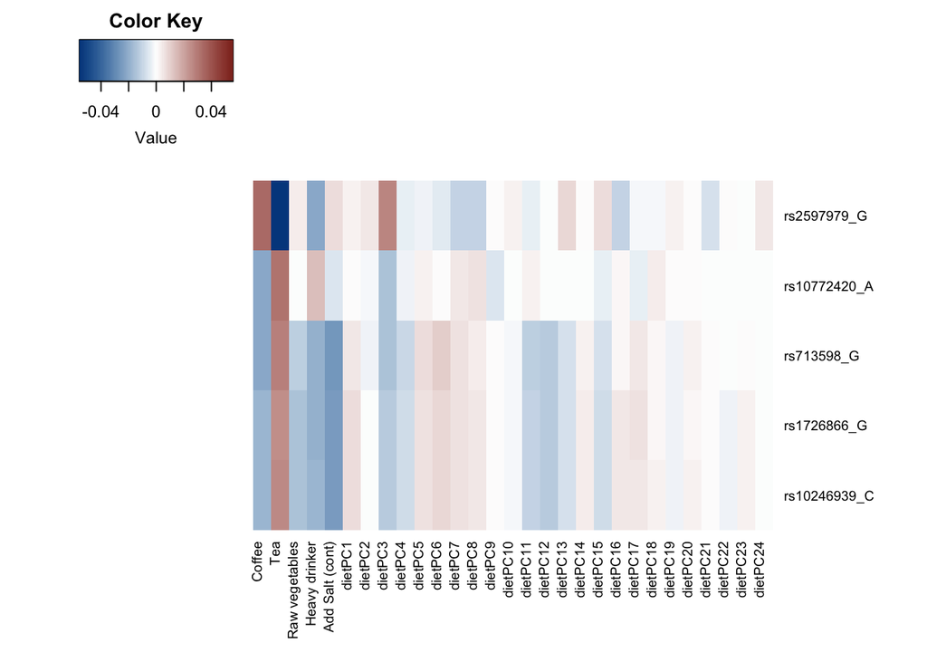

#### Associations of other bitter SNPs with glycenic measures

Bitter SNPs & RG

| Model | SNP_EA | Beta_95CI | P_t.test |
| --- | --- | --- | --- |
| Base | rs713598_G | -0.004 (-0.007, -0.001) | 0.014806 |
| BMI | rs713598_G | -0.004 (-0.007, -0.001) | 0.014110 |
| Lifestyle | rs713598_G | -0.004 (-0.007, 0) | 0.025653 |
| Diet | rs713598_G | -0.004 (-0.007, 0) | 0.029291 |
| Fib2Car | rs713598_G | -0.006 (-0.011, -0.001) | 0.018248 |
| SES | rs713598_G | -0.005 (-0.01, 0) | 0.059066 |
| AllDietPCs | rs713598_G | -0.004 (-0.007, 0) | 0.025185 |
| Base | rs1726866_G | -0.004 (-0.007, -0.001) | 0.013955 |
| BMI | rs1726866_G | -0.004 (-0.007, -0.001) | 0.013945 |
| Lifestyle | rs1726866_G | -0.004 (-0.007, 0) | 0.025791 |
| Diet | rs1726866_G | -0.004 (-0.007, 0) | 0.027250 |
| Fib2Car | rs1726866_G | -0.006 (-0.011, -0.001) | 0.016202 |
| SES | rs1726866_G | -0.005 (-0.01, 0) | 0.052159 |
| AllDietPCs | rs1726866_G | -0.004 (-0.007, -0.001) | 0.022916 |
| Base | rs10246939_C | -0.004 (-0.007, -0.001) | 0.012010 |
| BMI | rs10246939_C | -0.004 (-0.007, -0.001) | 0.011865 |
| Lifestyle | rs10246939_C | -0.004 (-0.007, -0.001) | 0.022235 |
| Diet | rs10246939_C | -0.004 (-0.007, -0.001) | 0.023603 |
| Fib2Car | rs10246939_C | -0.006 (-0.011, -0.001) | 0.013344 |
| SES | rs10246939_C | -0.005 (-0.011, 0) | 0.045563 |
| AllDietPCs | rs10246939_C | -0.004 (-0.007, -0.001) | 0.019822 |
| Base | rs10772420_A | -0.002 (-0.005, 0.001) | 0.248217 |
| BMI | rs10772420_A | -0.002 (-0.005, 0.001) | 0.224516 |
| Lifestyle | rs10772420_A | -0.002 (-0.005, 0.001) | 0.187483 |
| Diet | rs10772420_A | -0.002 (-0.005, 0.001) | 0.204871 |
| Fib2Car | rs10772420_A | -0.002 (-0.007, 0.003) | 0.450082 |
| SES | rs10772420_A | -0.002 (-0.008, 0.003) | 0.380761 |
| AllDietPCs | rs10772420_A | -0.002 (-0.005, 0.001) | 0.194852 |
| Base | rs2597979_G | 0.003 (-0.001, 0.007) | 0.101578 |
| BMI | rs2597979_G | 0.003 (-0.001, 0.007) | 0.096302 |
| Lifestyle | rs2597979_G | 0.004 (0, 0.008) | 0.071000 |
| Diet | rs2597979_G | 0.004 (0, 0.008) | 0.075532 |
| Fib2Car | rs2597979_G | 0.002 (-0.005, 0.008) | 0.632152 |
| SES | rs2597979_G | 0.002 (-0.005, 0.008) | 0.594050 |
| AllDietPCs | rs2597979_G | 0.004 (0, 0.008) | 0.069024 |

Bitter SNPs & 0-2hr Glucose

| Model | SNP_EA | Beta_95CI | P_t.test |
| --- | --- | --- | --- |
| Base | rs713598_G | -0.014 (-0.022, -0.006) | 0.000890 |
| BMI | rs713598_G | -0.014 (-0.022, -0.006) | 0.000957 |
| Lifestyle | rs713598_G | -0.013 (-0.021, -0.005) | 0.001336 |
| Diet | rs713598_G | -0.014 (-0.022, -0.005) | 0.001125 |
| Fib2Car | rs713598_G | -0.017 (-0.03, -0.005) | 0.007802 |
| SES | rs713598_G | -0.018 (-0.031, -0.005) | 0.008168 |
| AllDietPCs | rs713598_G | -0.013 (-0.022, -0.005) | 0.001244 |
| Base | rs1726866_G | -0.014 (-0.022, -0.005) | 0.000986 |
| BMI | rs1726866_G | -0.013 (-0.021, -0.005) | 0.001292 |
| Lifestyle | rs1726866_G | -0.013 (-0.021, -0.005) | 0.001859 |
| Diet | rs1726866_G | -0.013 (-0.021, -0.005) | 0.001607 |
| Fib2Car | rs1726866_G | -0.017 (-0.03, -0.004) | 0.008384 |
| SES | rs1726866_G | -0.018 (-0.031, -0.005) | 0.007876 |
| AllDietPCs | rs1726866_G | -0.013 (-0.021, -0.005) | 0.001744 |
| Base | rs10246939_C | -0.014 (-0.022, -0.006) | 0.000813 |
| BMI | rs10246939_C | -0.013 (-0.021, -0.005) | 0.001045 |
| Lifestyle | rs10246939_C | -0.013 (-0.021, -0.005) | 0.001522 |
| Diet | rs10246939_C | -0.013 (-0.021, -0.005) | 0.001326 |
| Fib2Car | rs10246939_C | -0.017 (-0.03, -0.005) | 0.007358 |
| SES | rs10246939_C | -0.018 (-0.031, -0.005) | 0.007126 |
| AllDietPCs | rs10246939_C | -0.013 (-0.021, -0.005) | 0.001453 |
| Base | rs10772420_A | -0.003 (-0.011, 0.005) | 0.531487 |
| BMI | rs10772420_A | -0.002 (-0.01, 0.006) | 0.601767 |
| Lifestyle | rs10772420_A | -0.002 (-0.01, 0.006) | 0.585589 |
| Diet | rs10772420_A | -0.002 (-0.01, 0.006) | 0.595316 |
| Fib2Car | rs10772420_A | -0.002 (-0.014, 0.011) | 0.798589 |
| SES | rs10772420_A | -0.002 (-0.015, 0.011) | 0.754347 |
| AllDietPCs | rs10772420_A | -0.002 (-0.01, 0.006) | 0.598136 |
| Base | rs2597979_G | 0.003 (-0.007, 0.013) | 0.574956 |
| BMI | rs2597979_G | 0.002 (-0.008, 0.012) | 0.651533 |
| Lifestyle | rs2597979_G | 0.003 (-0.007, 0.013) | 0.599203 |
| Diet | rs2597979_G | 0.003 (-0.007, 0.013) | 0.617208 |
| Fib2Car | rs2597979_G | 0.001 (-0.015, 0.017) | 0.935490 |
| SES | rs2597979_G | 0.001 (-0.016, 0.017) | 0.930377 |
| AllDietPCs | rs2597979_G | 0.003 (-0.007, 0.013) | 0.599515 |

#### Estimated marginal mean 0-2hr glucose for other SNPs

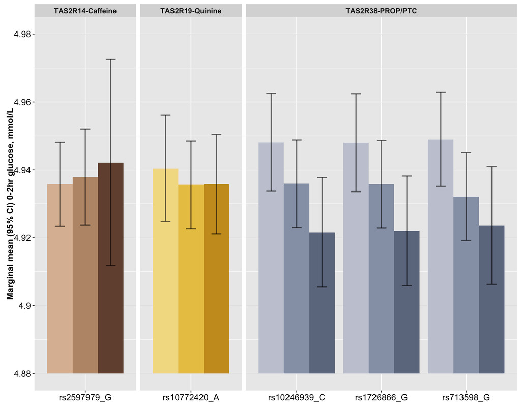

#### Take-aways

For Plausible kcal:

- No significant Diplotye x Plausible_kcal interaction
- In models with an interaction term, no significant diplotype-glucose associations…
- Plausible_kcal is the strongest predictor of RG (associations become less significant as you adjust for lifestyle then diet patterns)

Sex

- No significant Diplotype x Sex interactions in any model
- In models with a sex interaction term, no significant independent diplotype-glucose association
- Sex is a significant predictor in Lifestyle & Diet Patterns model

Income

- NO significant diplotype x income interaction in any model
- in models with interaction, no significant diplotye-glucose association
- income 31-52 & 52-100 significant predictors of lower RG relative to <18k in base model
- Associations are strengthened in the lifestyle and diet patterns model

Education

- Significant diplotype x education interaction (in some levels) in all models
- In models with interaction term, diplotype remains a significant predictor
- Interactions: College vs none of the above